# ADSP 31006 Time Series Analysis and Forecasting

# Assignment #4 - ARIMA and SARIMA

## Vishal Parameswaran

### Question 1:

Combine the data from the 16 files into a single dataset and plot it. Describe the dataset characteristics.

Ans:

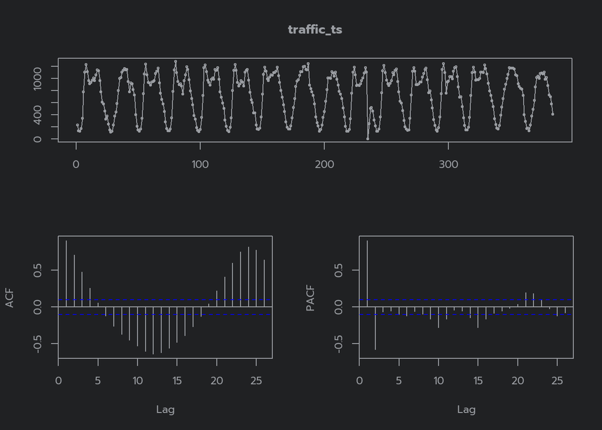

```r
traffic_df <- data.frame()
data_path = "/data/"
for (file_name in list.files(path=paste(getwd(), data_path, sep=""))) {
  file_path <- paste(getwd(), data_path, file_name, sep="")
  df <- read_excel(file_path)
  traffic_df <- bind_rows(traffic_df, df %>% slice(5:28) %>% select(c(3,5)))
}

traffic_ts <- ts(data = as.numeric(traffic_df[, 2]),  frequency = 1)
tsdisplay(traffic_ts)
```

We can see strong seasonality in the data. The data is also non-stationary as the variance are not constant over time. There is no trend in the data as the mean is constant over time. The ACF plot shows that there is no trend as the data is not slowly moving towards 0, instead it is fluctuating around the mean, indicating a strong seasonality. The PACF shows a high correlation at the first 2 lags.

### Question 2:

Split the dataset into a training dataset which includes 6/16/2013 - 6/30/2013 samples and a test dataset which includes 7/1/2013 samples and plot the ACF and PACF.

Ans:

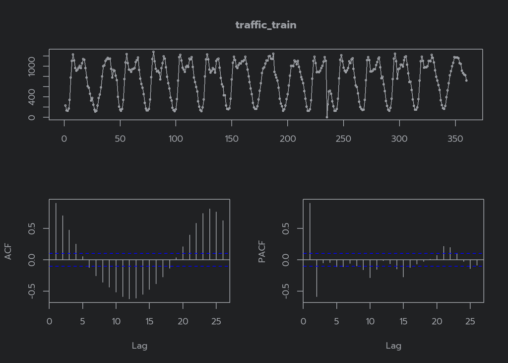

```r
traffic_train <- window(traffic_ts, end = 360) # start date of the dataset is 6/16/2013 and between 6/16/2013 and 6/30/2013 there are 15 days and each day has 24 hours so 15*24 = 360
traffic_test <- window(traffic_ts, start = 361) # start from the end of the previous window

tsdisplay(traffic_train) # can use individual plots as well, the tsdisplay function is a more compact way of plotting the ACF and PACF
```

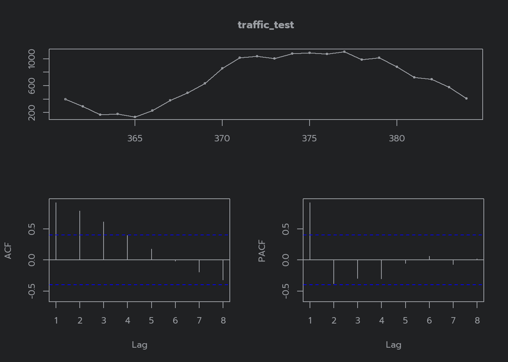

```r
tsdisplay(traffic_test)# can use individual plots as well, the tsdisplay function is a more compact way of plotting the ACF and PACF
```

### Question 3:

Build an $ARIMA(p, d, q)$ model using the training dataset and R auto.arima() function. Change the values of $p$ and $q$ and determine the best model using AICc and BIC values. Do AICc and BICselect the same model as the best model? For each derived model, review the residual plots for the residuals ACF and normality.

Ans: Lets test for stationarity:

```r
kpss.test(traffic_train)
```

```
##
##  KPSS Test for Level Stationarity
##
## data:  traffic_train
## KPSS Level = 0.038755, Truncation lag parameter = 5, p-value = 0.1
```

since the p value is >0.1 we can conclude that the data is null stationarity.

Lets use auto arima to find the best model:

```r
best_model <- auto.arima(traffic_train)
best_model
```

```
## Series: traffic_train
## ARIMA(2,0,3) with non-zero mean
##
## Coefficients:
##          ar1      ar2      ma1      ma2      ma3      mean
##       1.7986  -0.8728  -0.4950  -0.2736  -0.1415  744.5472
## s.e.  0.0300   0.0299   0.0589   0.0591   0.0631    7.7809
##
## sigma^2 = 13761:  log likelihood = -2224.92
## AIC=4463.85   AICc=4464.17   BIC=4491.05
```

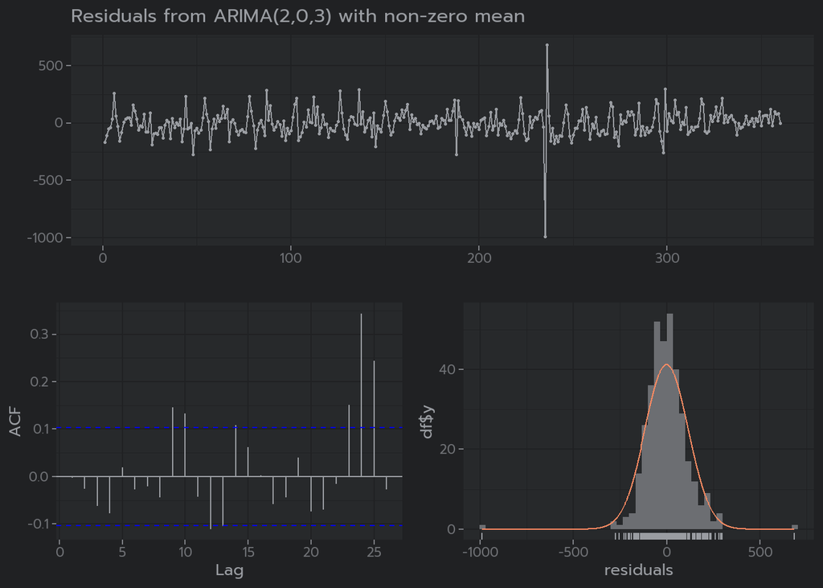

```
##
##  Ljung-Box test
##
## data:  Residuals from ARIMA(2,0,3) with non-zero mean
## Q* = 19.713, df = 5, p-value = 0.001415
##
## Model df: 5.   Total lags used: 10
```

```r
checkresiduals(best_model)
```

Given that the p-value in this scenario is 0.001415, which is below the chosen significance level, it leads us to reject the null hypothesis, indicating the presence of significant residual autocorrelation within the ARIMA(2,0,3) model.

Lets try to find a better model by changing the values of p and q:

```r
eacf(traffic_train)
```

```
## AR/MA
##   0 1 2 3 4 5 6 7 8 9 10 11 12 13
## 0 x x x x o x x x x x x  x  x  x
## 1 x x x x o x x x o o x  x  x  x
## 2 o o x o o o o x x o o  x  x  x
## 3 x o o x o o o o o o o  o  x  o
## 4 x x o x o o o o o o o  o  x  o
## 5 x x x o o o o o o o o  o  o  o
## 6 x x x x o o o o o o o  o  o  o
## 7 x o o x x o o o o x o  o  o  o
```

Lets test the 2,0,0 and the 2,0,1 and 2,0,4 models:

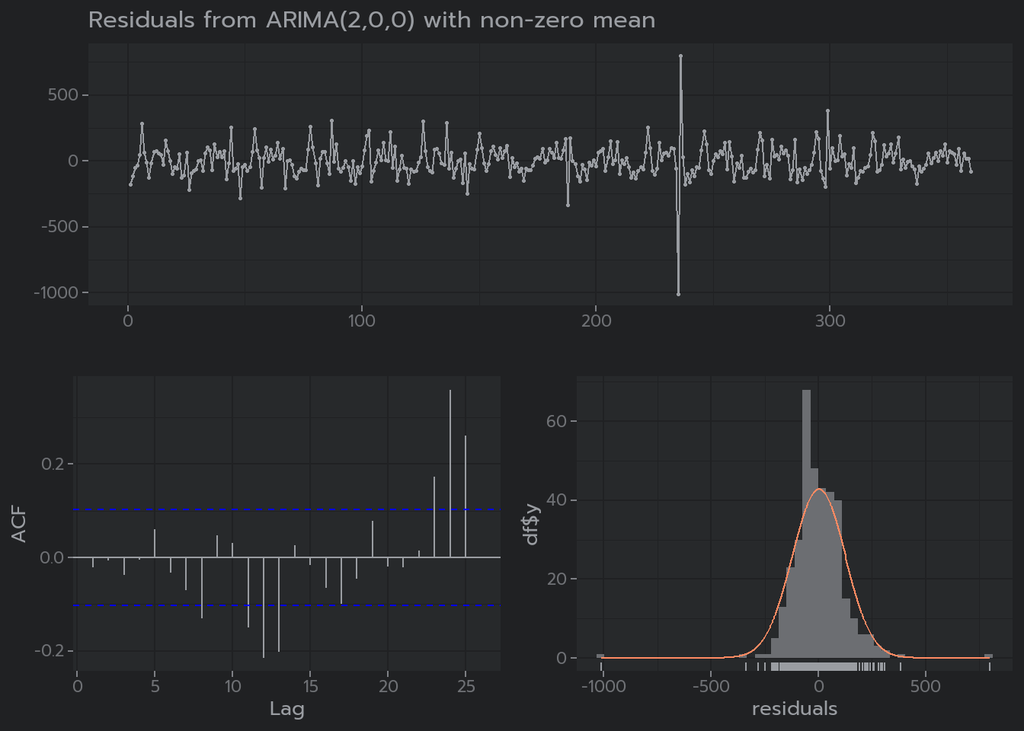

```
##
##  Ljung-Box test
##
## data:  Residuals from ARIMA(2,0,0) with non-zero mean
## Q* = 11.919, df = 8, p-value = 0.1548
##
## Model df: 2.   Total lags used: 10
```

```r
model_2_0_0 <- Arima(traffic_train, order = c(2,0,0))
model_2_0_1 <- Arima(traffic_train, order = c(2,0,1))
model_2_0_4 <- Arima(traffic_train, order = c(2,0,4))

checkresiduals(model_2_0_0)
```

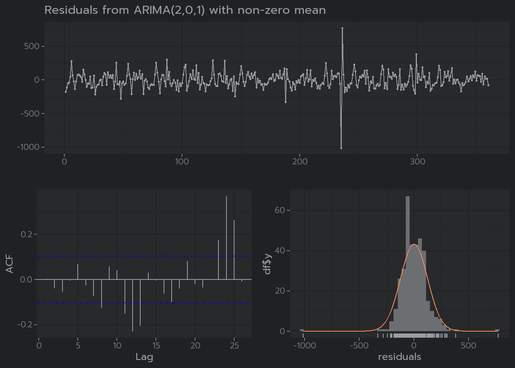

```
##
##  Ljung-Box test
##
## data:  Residuals from ARIMA(2,0,1) with non-zero mean
## Q* = 13.304, df = 7, p-value = 0.06504
##
## Model df: 3.   Total lags used: 10
```

```r
checkresiduals(model_2_0_1)
```

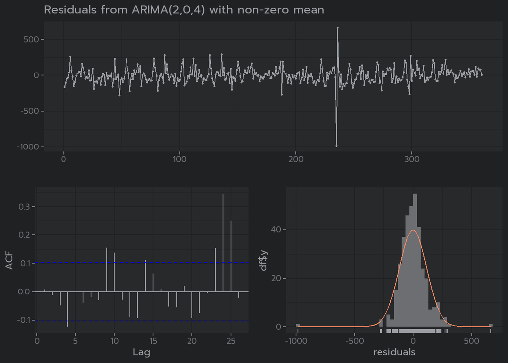

```
##
##  Ljung-Box test
##
## data:  Residuals from ARIMA(2,0,4) with non-zero mean
## Q* = 23.332, df = 4, p-value = 0.0001087
##
## Model df: 6.   Total lags used: 10
```

```r
checkresiduals(model_2_0_4)
```

lets check some other models like 3,0,2 3,0,11 7,0,2 7,0,5 and 6,0,11 :

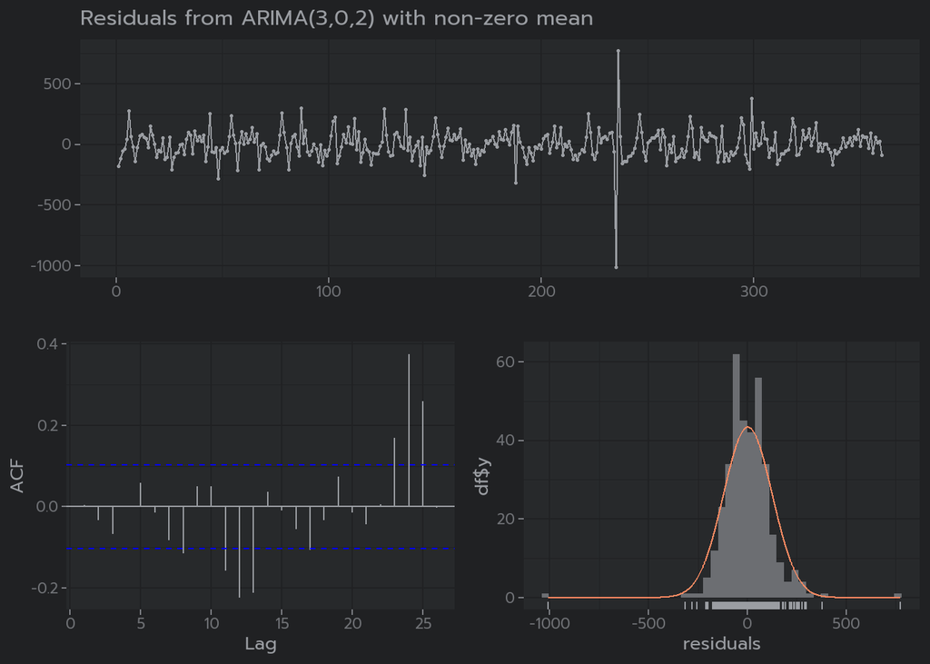

```
##
##  Ljung-Box test
##
## data:  Residuals from ARIMA(3,0,2) with non-zero mean
## Q* = 12.774, df = 5, p-value = 0.0256
##
## Model df: 5.   Total lags used: 10
```

```r
model_3_0_2 <- Arima(traffic_train, order = c(3,0,2))
model_3_0_11 <- Arima(traffic_train, order = c(3,0,11))
model_7_0_2 <- Arima(traffic_train, order = c(7,0,2))
model_7_0_5 <- Arima(traffic_train, order = c(7,0,5))
model_6_0_11 <- Arima(traffic_train, order = c(6,0,11))

checkresiduals(model_3_0_2)
```

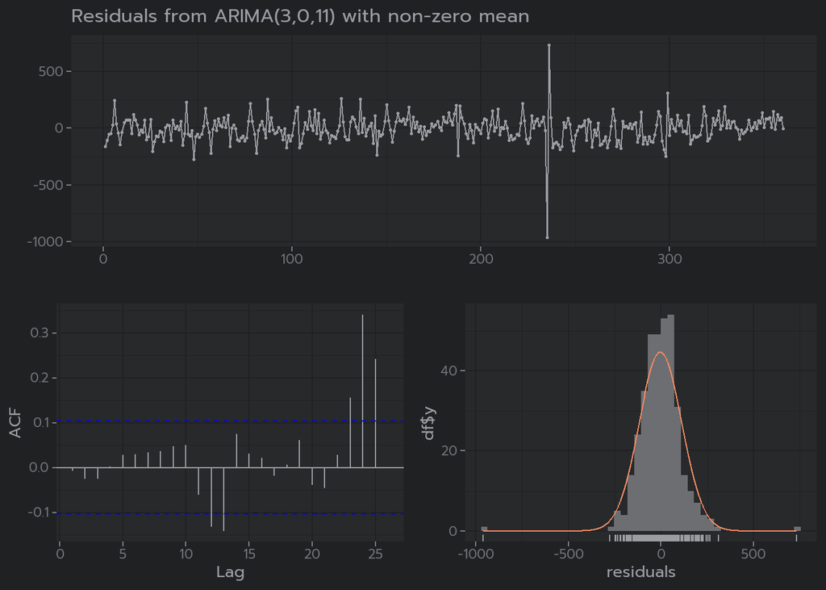

```
##
##  Ljung-Box test
##
## data:  Residuals from ARIMA(3,0,11) with non-zero mean
## Q* = 21.96, df = 3, p-value = 6.648e-05
##
## Model df: 14.   Total lags used: 17
```

```r
checkresiduals(model_3_0_11)
```

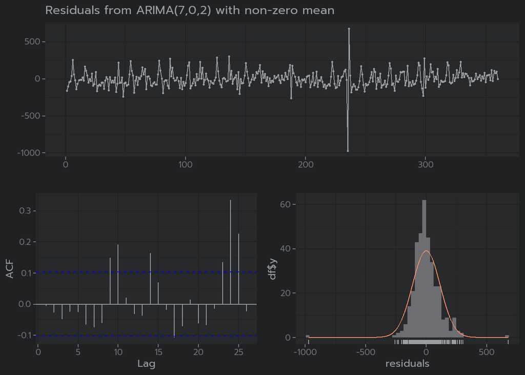

```
##
##  Ljung-Box test
##
## data:  Residuals from ARIMA(7,0,2) with non-zero mean
## Q* = 29.028, df = 3, p-value = 2.209e-06
##
## Model df: 9.   Total lags used: 12
```

```r
checkresiduals(model_7_0_2)
```

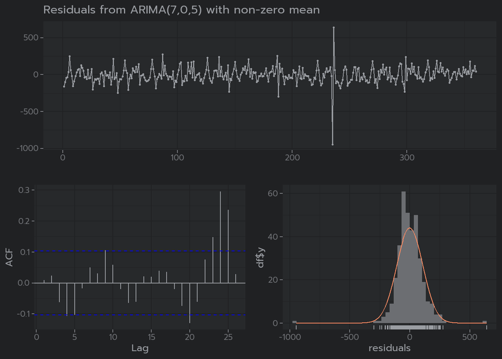

```
##
##  Ljung-Box test
##
## data:  Residuals from ARIMA(7,0,5) with non-zero mean
## Q* = 19.917, df = 3, p-value = 0.0001766
##
## Model df: 12.   Total lags used: 15
```

```r
checkresiduals(model_7_0_5)
```

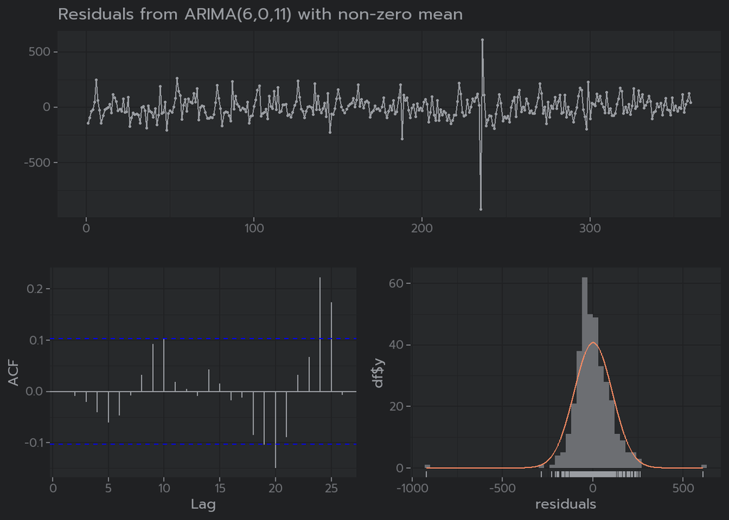

```
##
##  Ljung-Box test
##
## data:  Residuals from ARIMA(6,0,11) with non-zero mean
## Q* = 27.128, df = 3, p-value = 5.534e-06
##
## Model df: 17.   Total lags used: 20
```

```r
checkresiduals(model_6_0_11)
```

lets compare the AIC and BIC values for the above models:

```r
comparision = data.frame(best_model[c('aicc', 'bic')])
names(comparision) = c('aicc', 'bic')
comparision = rbind(comparision, data.frame(model_2_0_0[c('aicc', 'bic')]))
comparision = rbind(comparision, data.frame(model_2_0_1[c('aicc', 'bic')]))
comparision = rbind(comparision, data.frame(model_2_0_4[c('aicc', 'bic')]))
comparision = rbind(comparision, data.frame(model_3_0_2[c('aicc', 'bic')]))
comparision = rbind(comparision, data.frame(model_3_0_11[c('aicc', 'bic')]))
comparision = rbind(comparision, data.frame(model_7_0_2[c('aicc', 'bic')]))
comparision = rbind(comparision, data.frame(model_7_0_5[c('aicc', 'bic')]))
comparision = rbind(comparision, data.frame(model_6_0_11[c('aicc', 'bic')]))

comparision$model = c('(2,0,3)', '(2,0,0)', '(2,0,1)', '(2,0,4)', '(3,0,2)', '(3,0,11)', '(7,0,2)',  '(7,0,5)','(6,0,11)')

comparision = comparision[order(comparision$aicc,comparision$bic),]

comparision
```

```
##       aicc      bic    model
## 9 4424.751 4496.351 (6,0,11)
## 8 4446.255 4499.443  (7,0,5)
## 7 4459.709 4501.697  (7,0,2)
## 1 4464.166 4491.051  (2,0,3)
## 4 4465.644 4496.322  (2,0,4)
## 6 4483.519 4544.111 (3,0,11)
## 2 4500.407 4515.838  (2,0,0)
## 3 4501.815 4521.076  (2,0,1)
## 5 4503.834 4530.719  (3,0,2)
```

```r
best_model = model_6_0_11
```

### Question 4:

Build a day of the week seasonal $ARIMA(p, d, q)(P,Q,D)_{s}$ model using the training dataset and R auto.arima() function.

Ans:

```r
weekly_data <- ts(data = as.numeric(traffic_df[1:360, 2]),  frequency = 168)

weekly_model <- auto.arima(weekly_data, seasonal = TRUE)
weekly_model
```

```
## Series: weekly_data
## ARIMA(1,0,1)(0,1,0)[168]
##
## Coefficients:
##          ar1     ma1
##       0.4773  0.2506
## s.e.  0.1023  0.1168
##
## sigma^2 = 9623:  log likelihood = -1152.2
## AIC=2310.4   AICc=2310.53   BIC=2320.17
```

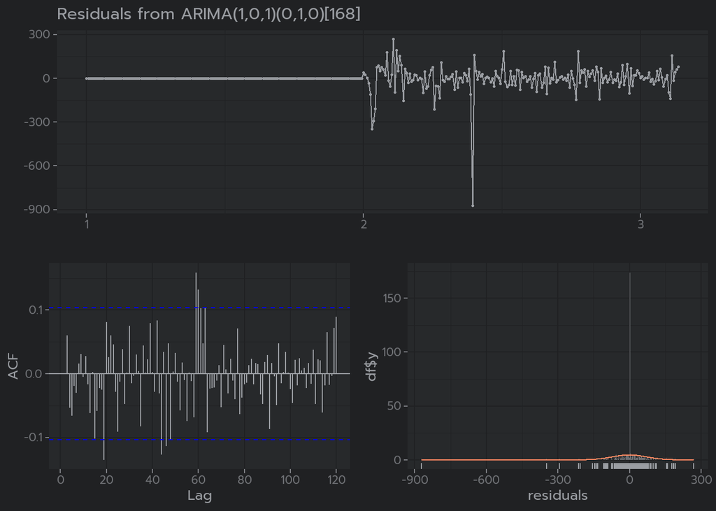

```
##
##  Ljung-Box test
##
## data:  Residuals from ARIMA(1,0,1)(0,1,0)[168]
## Q* = 102.16, df = 70, p-value = 0.007314
##
## Model df: 2.   Total lags used: 72
```

```r
checkresiduals(weekly_model)
```

### Question 5:

Use the $ARIMA(p, d, q)(P,Q,D)_{s}$ model from Question 4 to forecast for July 1st (which is a Monday). Plot your result. Ans:

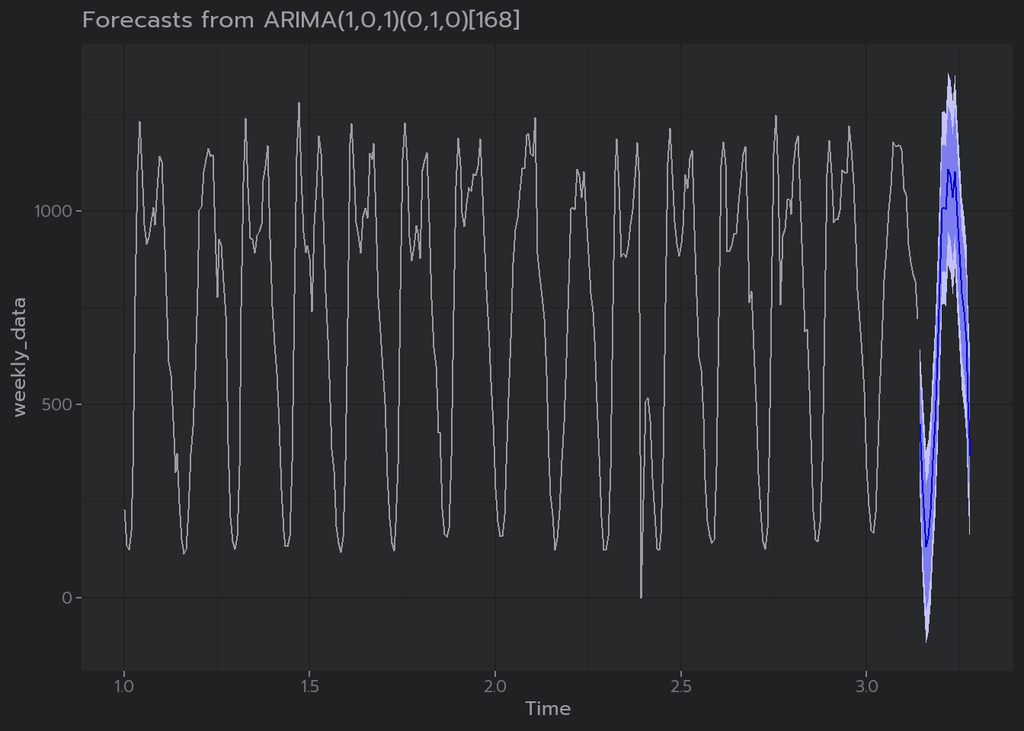

```r
forecast_weekly = forecast(weekly_model, h = 24)
autoplot(forecast_weekly)
```

From the forecast wecan see that the model captures the seasonality of the data, and the forecast is pretty accurate.

### Question 6:

Build a hour of the day seasonal $ARIMA(p, d, q)(P,Q,D)_{s}$ model using the training dataset and R auto.arima() function.

Ans:

```r
hourly_data <- ts(data = as.numeric(traffic_df[1:360, 2]),  frequency = 24)

hourly_model <- auto.arima(hourly_data, seasonal = TRUE)
hourly_model
```

```
## Series: hourly_data
## ARIMA(2,0,2)(2,1,0)[24]
##
## Coefficients:
##          ar1      ar2      ma1      ma2     sar1     sar2
##       1.5852  -0.6770  -0.6443  -0.1877  -0.5062  -0.3616
## s.e.  0.0740   0.0532   0.0903   0.0754   0.0531   0.0530
##
## sigma^2 = 11225:  log likelihood = -2046.24
## AIC=4106.48   AICc=4106.82   BIC=4133.2
```

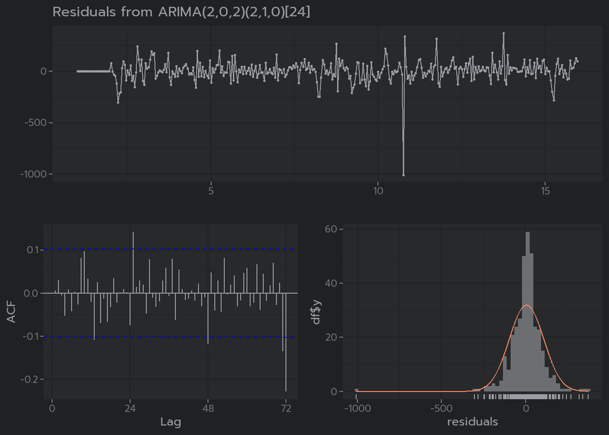

```
##
##  Ljung-Box test
##
## data:  Residuals from ARIMA(2,0,2)(2,1,0)[24]
## Q* = 46.556, df = 42, p-value = 0.2904
##
## Model df: 6.   Total lags used: 48
```

```r
checkresiduals(hourly_model)
```

### Question 7:

Use the $ARIMA(p, d, q)(P,Q,D)_{s}$ model from Question 6 to forecast for July 1st (which is a Monday). Plot your result.

Ans:

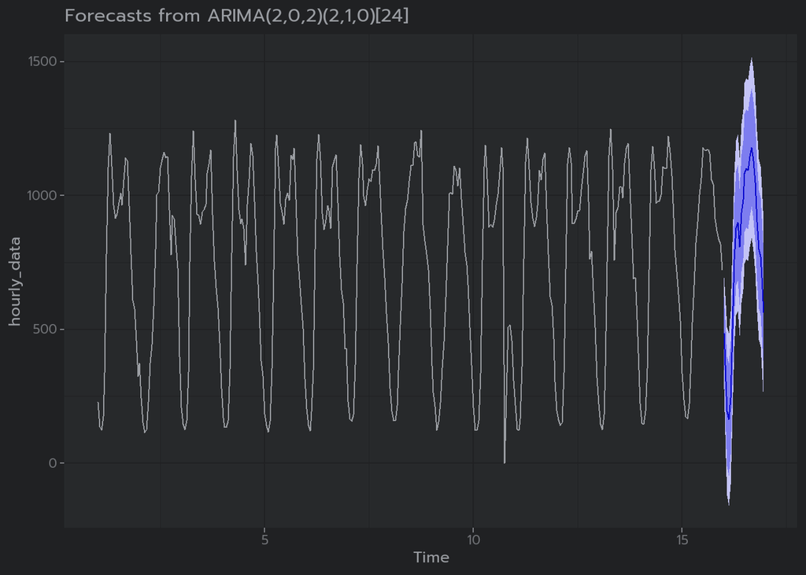

```r
forecast_hourly = forecast(hourly_model, h = 24)

autoplot(forecast_hourly)
```

This model is also able to accurately capture the seasonality of the data and the forecast is pretty accurate.

### Question 8:

Compare the forecast of the models from Questions 5 and 7 for July 1 8:00, 9:00, 17:00 and 18:00, which model is better (Questions 4 or 6)? Ans:

```r
hourly_window <- window(forecast_hourly$mean,start=1)
weekly_window <- window(forecast_weekly$mean, start = 1)
```

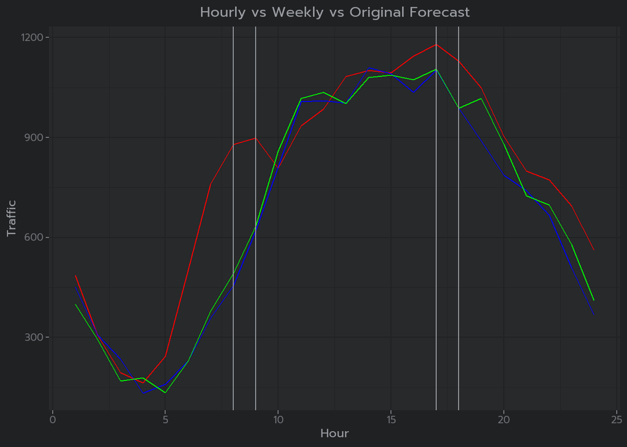

```r
# hourly_df <- data.frame(hourly_window)

ggplot() + geom_line(aes(x = 1:24, y = hourly_window), color = "red") + geom_line(aes(x = 1:24, y = weekly_window), color = "blue")   + geom_line(aes(x = 1:24, y = traffic_test), color = "green")  + geom_vline(xintercept = 8)  + geom_vline(xintercept = 9)  + geom_vline(xintercept = 17)  + geom_vline(xintercept = 18)   + labs(x = "Hour", y = "Traffic")   + ggtitle("Hourly vs Weekly vs Original Forecast")   + theme(plot.title = element_text(hjust = 0.5))
```

From the above plot we can see that the blue model or the Weekly model is better as its closer to the original dataset. The red model or the hourly model is not as accurate as the weekly model, probably because the hourly model might be confused on a per day basis, while the weekly model has a more broader view of the data.